# Large-scale Distributed $k$-means Algorithm

In this Notebook, we'll focus on the development of a simple distributed algorithm. As for the Notebook on SGD, we focus on iterative algorithms, which eventually converge to a desired solution.

In what follows, we'll proceed with the following steps:

- We first introduce formally the $k$-means algorithm
- Then we focus on a serial implementation. To do this, we'll first generate some data using scikit. In passing, we'll also use the $k$-means implementation in scikit to have a baseline to compare against.
- Subsequently, we will focus on some important considerations and improvements to the serial implementation of $k$-means.
- At this point, we'll design our distributed version of the $k$-means algorithm using pyspark, and re-implement the enhancements we designed for the serial version

#### References:

- https://en.wikipedia.org/wiki/K-means_clustering
- http://nbviewer.jupyter.org/github/ethen8181/machine-learning/blob/master/clustering/kmeans.ipynb
- https://apache.googlesource.com/spark/+/master/examples/src/main/python/kmeans.py
- https://github.com/castanan/w2v/blob/master/ml-scripts/w2vAndKmeans.py

#### Preamble code

```python
%matplotlib inline
import numpy as np
import pandas as pd
import matplotlib.pyplot as plt
from scipy.stats import norm
from sklearn.cluster import KMeans
from sklearn.metrics import pairwise_distances
from sklearn.datasets.samples_generator import make_blobs
import time
from random import randint
```

# Preliminaries: the $k$-means algorithm

$k$-means clustering aims to partition $n$ $d-$dimensional observations into $k$ clusters in which each observation belongs to the cluster with the nearest mean, serving as a prototype of the cluster. This results in a partitioning of the data space into Voronoi cells. The problem is computationally difficult (NP-hard); however, there are efficient heuristic algorithms that are commonly employed and converge quickly to a local optimum. In this Notebook we'll focus on one of them in particular: the Lloyd algorithm.

The $k$-means problem can be formalized as follows. Given a set of observations $(x_1, x_2, \cdots, x_n)$, where each observation is a $d$-dimensional real vector, $k$-means clustering aims to partition the $n$ observations into $k \leq n$ sets $S = \{S_1, S_2, \cdots, S_k\}$ so as to minimize the within-cluster sum of squares (WCSS) (i.e. variance). The objective is to find:

$$ \arg \min_S \sum_{i=1}^{k} \sum_{x \in S_i} || \boldsymbol{x} - \boldsymbol{\mu_i} ||^2 $$

The most common algorithm uses an iterative refinement technique. Given an initial set of $k$ centroids $\mu_1^{(1)}, \cdots, \mu_k^{(1)}$ , the algorithm proceeds by alternating between two steps: in the **assignment step**, observations are associated to the closest **centroid**, in terms of squared Euclidean distance; in the **update step** new centroids are computed based on the new points associated to each centroid. Note: $\mu_i^{(t)}$ stands for the $i$-th centroid as of the $t$-th iteration. So $\mu_1^{(1)}$ is the centroid 1 at iteration 1.

## Algorithm pseudo-code

It is important to work on a principled approach to the design of large-scale algorithms, and this starts with using good data structures and scientific libraries, such as `numpy` and `scipy`. In particular, we will focus on the use of `numpy` arrays, which come with efficient methods for array operations. A pseudo-code for the $k$-means algorithm is specified below:

```
def kmeans(X, k, maxiter, seed=None):
    """
    specify the number of clusters k and
    the maximum iteration to run the algorithm
    """

    # randomly choose k data points as initial centroids
    centroids = X[rand_indices]

    for itr in range(maxiter):
        # ---------------
        # ASSIGNMENT STEP
        # ---------------
        # compute the distance matrix between each data point and the set of centroids
        distance_matrix = # row Index = data point Index; col Index = centroid Index; value=distance
        # assign each data point to the closest centroid
        cluster_assignment = # array Index = data point Index; array value = closest centroid Index

        # UPDATE STEP
        # select all data points that belong to cluster i and compute
        # the mean of these data points (each feature individually)
        # this will be our new cluster centroids
        new_centroids = ...

        # STOP CONDITION
        # if centroids == new_centroids => stop
```

# Synthetic data generation: working in bi-dimensional spaces

Next, we use sklearn to generate some synthetic data to test our algorithm.

```python
X, y = make_blobs(n_samples = 300, centers = 4,
                  random_state = 0, cluster_std = 0.6)
```

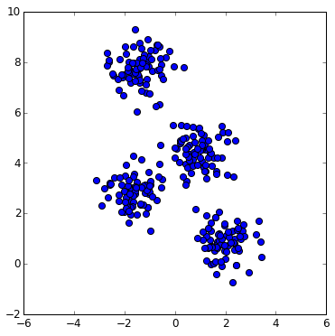

```python
# change default figure and font size
plt.rcParams['figure.figsize'] = 8, 6
plt.rcParams['font.size'] = 12

# scatter plot
plt.scatter(X[:, 0], X[:, 1], s = 50)
plt.ylim(-2, 10)
plt.xlim(-6, 6)
plt.gca().set_aspect('equal')
plt.show()
```

**Question 1.** Implement your own version of k-means, as a serial algorithm. Follow the guidelines below:

- Define a function to perform k-means clustering. The function should accept as inputs: the training data x, the number of clusters k, and the iteration budget you allocate to the algorithm. Additional arguments might include the use of a random seed to initialize centroids.
- The function should output the centroids, and the cluster assignment, that is, to which centroid each data point is assigned to
- Optionally, keep track of the position of the centroids, for each iteration.

Once the ```kmeans``` function is defined, you can generate input data according to the cell above, that uses scikitlearn.  
The output of your cell should contain the following information:

- Print the number of data points that belong to each cluster
- Plot the clustered data points:
- Using different colors for each cluster
- Plot the centroid positions for each cluster

```
Cluster 0 contains: 75 elements
Cluster 1 contains: 75 elements
Cluster 2 contains: 75 elements
Cluster 3 contains: 75 elements
```

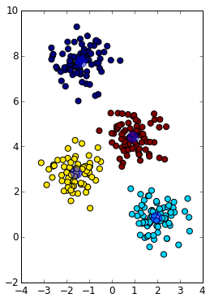

```python
centroid_history = []

def kmeans(X, k, max_iter, seed=None, select_centroids="random", centroid_history=None):
    """
    #TODO
    """
    #starting computational time
    start_time = time.time()

    n_row, n_col = X.shape

    # randomly choose k data points as initial centroids
    if seed is not None:
        np.random.seed(seed)

    # choice the initial centroids depending on the passed option
    if select_centroids is "random":
        rand_indices = np.random.choice(n_row, size = k, replace=False)
        centroids = X[rand_indices]
    elif select_centroids is "kmeanpp":
        # 1) initilize the centroid vector and select the first random point
        centroids = np.zeros((k, n_col))
        rand_index = np.random.choice(n_row)
        centroids[0] = X[rand_index]

        # 2) compute all the distances from the selected centroid.
        # Flaten due to np.random.choice(P-> requires a 1-D array)
        distances = pairwise_distances(X, [centroids[0]], metric = 'euclidean').flatten()

        # 3) compute the remaining k-1 centroids
        for i in range(1, k):
            # choose the next centroid, the probability for each data point to be chosen
            # is directly proportional to its squared distance from the nearest centroid
            prob = distances ** 2
            rand_index = np.random.choice(n_row, size = 1, p = prob / np.sum(prob))
            centroids[i] = X[rand_index]

            if i == k - 1:
                break

            # if we still need another cluster,
            # compute distances from the centroids to all data points
            # and update the squared distance as the minimum distance to all centroid
            distances_new = pairwise_distances(X, [centroids[i]], metric = 'euclidean').flatten()
            distances = np.min(np.vstack((distances, distances_new)), axis = 0)

    # save the initial centroid history
    if centroid_history is not None:
        centroid_history.append(centroids)

    for epoch in range(max_iter):
        # compute distances between each data point and the set of centroids
        # and assign each data point to the closest centroid
        distances_to_centroids = pairwise_distances(X, centroids, metric = 'euclidean')

        # axis=1 is checking the row for the minimum index
        cluster_assignment = np.argmin(distances_to_centroids, axis = 1)

        # select all data points that belong to cluster i and compute
        # the mean of these data points (each feature individually)
        # this will be our new cluster centroids

        # NOTE: cluster assignent is mapped as a boolean values which are used to filter the X vectot
        # then the mean is perfomed for the resulting vector
        new_centroids = np.array([X[cluster_assignment == i].mean(axis = 0) for i in range(k)])

        # save the centroid history
        if centroid_history is not None:
            centroid_history.append(new_centroids)

        # if the updated centroid is still the same,
        # then the algorithm converged
        if np.all(centroids == new_centroids):
            break

        centroids = new_centroids

    # compute the heterogeneity
    heterogeneity = 0
    for i in range(k):
        # we take the data points which are associated with the cluster i-th
        cluster_data = X[cluster_assignment == i]
        distances = pairwise_distances(cluster_data, [centroids[i]], metric = 'euclidean')
        # we implement the summation
        heterogeneity += np.sum(distances ** 2)

    # end computational time
    end_time = time.time()

    return centroids, cluster_assignment, heterogeneity, end_time - start_time

# print the number of points for each cluster
def print_clust_size(cluster_assignment, k):
    for i in range(k):
        print ("Cluster " + str(i) + " contains: " + str(len(cluster_assignment[cluster_assignment == i])) + ' elements')


def plot_cluster(cluster_assignment, centroids, data, title=''):
    # scatter plot
    plt.scatter(X[:, 0], X[:, 1], s = 50, c=cluster_assignment)
    plt.scatter(centroids[:, 0], centroids[:, 1], s = 200, alpha = 0.5)

    plt.gca().set_aspect('equal')
    plt.title(title)
    plt.show()


def print_centroid_hist(centroid_history):
    for centroid in centroid_history:
        plt.scatter(centroid[:, 0], centroid[:, 1], s = 200, alpha = 0.5)

K = 4
MAX_ITER = 100
SEED = 1
centroids, label, heterogen, running_time = kmeans(X, K, MAX_ITER, centroid_history=centroid_history, seed=SEED)
print_clust_size(label, K)
plot_cluster(label, centroids, X)
#print_centroid_hist(centroid_history)
```

**Question 2.** Use the built-in k-means implementation in sklearn and determine centroids and clusters. Follow the guidelines below:

- Use the KMeans algorithm from sklearn
- Use the fit_predict method to cluster data
- Use the cluster_centers_ method to retrieve centroids

The output of your cell should contain the following information:

- Plot the clustered data points, using the same code your have produced for Question.1
- Using different colors for each cluster
- Plot the centroid positions for each cluster

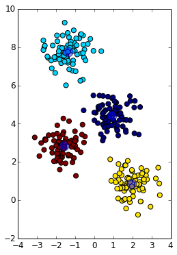

```python
# the init='random' is similar to our implementation. init="k-means++" is a smart selection to speed up convergence
k_means = KMeans(K, 'random', 1, MAX_ITER)
labels = k_means.fit_predict(X)
centroids = k_means.cluster_centers_

plot_cluster(labels, centroids, X)
```

**Question 3.** Use the sklearn dataset API to generate alternative synthetic data to test your k-means algorithm implementation. Follow the guidelines from this document: http://scikit-learn.org/stable/auto_examples/cluster/plot_cluster_comparison.html#sphx-glr-auto-examples-cluster-plot-cluster-comparison-py The output of your cell should contain the following information:

- Plot the new synthetic dataset you generated
- Plot the clustered data points, using the same code your have produced for Question.1
- Using different colors for each cluster
- Plot the centroid positions for each cluster

```
Cluster 0 contains: 76 elements
Cluster 1 contains: 77 elements
Cluster 2 contains: 72 elements
Cluster 3 contains: 75 elements
```

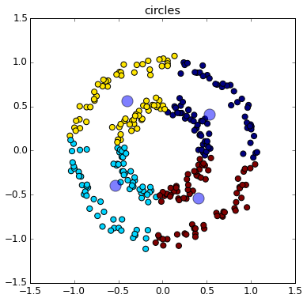

```
Cluster 0 contains: 75 elements
Cluster 1 contains: 75 elements
Cluster 2 contains: 75 elements
Cluster 3 contains: 75 elements
```

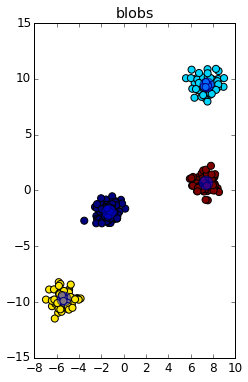

```
Cluster 0 contains: 76 elements
Cluster 1 contains: 74 elements
Cluster 2 contains: 75 elements
Cluster 3 contains: 75 elements
```

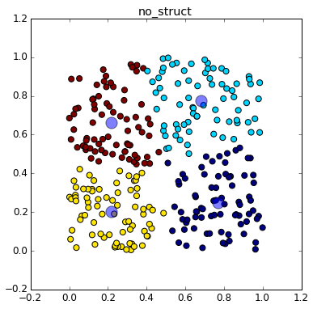

```
Cluster 0 contains: 57 elements
Cluster 1 contains: 87 elements
Cluster 2 contains: 64 elements
Cluster 3 contains: 92 elements
```

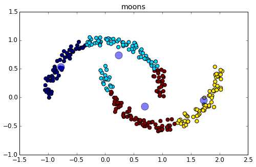

```python
from sklearn import datasets

n_samples = 300
samples = {}
samples["circles"] = datasets.make_circles(n_samples=n_samples, factor=.5, noise=.05)
samples["moons"] = datasets.make_moons(n_samples=n_samples, noise=.05)
samples["blobs"] = make_blobs(n_samples=n_samples, centers=4, random_state=8, cluster_std=0.6)
samples["no_struct"] = np.random.rand(n_samples, 2), None


for key in samples:
    X, y = samples[key]
    centroids, label, heterogen, running_time = kmeans(X, K, MAX_ITER, centroid_history=centroid_history, seed=SEED)
    print_clust_size(label, K)
    plot_cluster(label, centroids, X, key)
```

# A simplified analysis of algorithm convergence

One well-known weakness of $k$-means is that the algorithm's performance is closely tied with the randomly generated initial centroids' quality. If the algorithm starts with a set of bad inital centers, it will get stuck in a local minimum.

Instead of taking a formal approach to study the convergence of $k$-means, let's study it with an experimental approach. One thing we can do is to build a measure of clustering quality: intuitively, a good clustering result should produce clusters in which data points should be very close to their centroids, and very far from other centroids. In this Notebook, we'll look at a metric called the **total within Sum of Squares**, which is sometimes referred ot as heterogeneity. Mathematically, we define heterogeneity as:

$$ \mathcal{H} = \sum_{j=1}^{k} \sum_{i: z_i=j} || \boldsymbol{x_i} - \boldsymbol{\mu_j}||_{2}^{2} $$

Where $k$ denotes the total number of clusters, $x_i$ is the $i$-th data point, $\mu_j$ is the $j$-th centroid, and $|| \cdot ||_{2}^{2}$ denotes the squared L2 norm (Euclidean distance) between the two vectors.

**Question 4.** Modify your own version of k-means, to compute heterogeneity as defined above. Follow the guidelines below:

- Use the same method template you used in Question 1
- Add the code required to compute heterogeneity
- The function should return, in addition to the same return values as for the baseline version, the computed heterogeneity

**Answer 4**  
Our function is already returning the hererogeneity value.

**Question 5.** Using the modified k-means method you designed, study algorithm convergence as a function of heterogeneity. Follow the guidelines below:

- Run the modified k-means for at least 5 different initial seed values
- Prepare a dictionary data structure containing: key = random seed, value = heterogeneity
- Print seed, heterogeneity values

Add your personal comment about the convergence properties of the $k$-means algorithm.

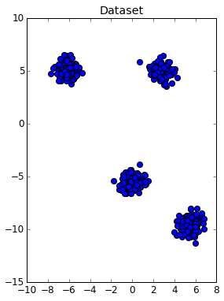

```
Results:
SEED = 245	H = 313.84
SEED = 40	H = 313.84
SEED = 705	H = 5238.23
SEED = 441	H = 5238.47
SEED = 877	H = 3237.02
```

```python
X, y = make_blobs(n_samples = 500, centers = 4,
                  random_state = 10, cluster_std = 0.6)

# change default figure and font size
plt.rcParams['figure.figsize'] = 8, 6
plt.rcParams['font.size'] = 12

# scatter plot
plt.scatter(X[:, 0], X[:, 1], s = 50)
plt.gca().set_aspect('equal')
plt.title('Dataset')
plt.show()


SEEDS = [randint(1, 1000) for x in range(5)]
res = {}

for s in SEEDS:
    res[s] = kmeans(X, K, MAX_ITER, seed=int(s))

print("\n\nResults:")
for i in range(len(SEEDS)):
    s = SEEDS[i]
    print("SEED = {}\tH = {}".format(int(s), round(res[s][2], 2)))
```

The K-means algorithm converges to a local minimum: then, the quality of the final result strongly depends on the starting conditions of the algorithm. In our case, seeds are the main success factor because initial centroids are chosen randomly. As you can see from the results we obtained, there exist some seeds for which the computations lead us to worse final results

# A technique for a smart centroid initialization: $k$-means++

One effective way to produce good initial centroids to feed to $k$-means is to proceed as follows: instead of randomly generating initial centroids, we will try to spread them out in our $d$-dimensional space, such that they are not "too close" to eachother. If you are interested in the details of this technique, you should refer to the link to the original research paper below: in summary, the $k$-means++ technique allows to improve the quality of the local optima in which $k$-means settles, and to reduce the average runtime of the algorithm.

k-means++: the advantages of careful seeding, by David Arthur and Sergei Vassilvitskii (Stanford University) https://dl.acm.org/citation.cfm?id=1283494

A simplified workflow of the $k$-means++ approach is as follows:

- Choose a data point at random from the dataset, this serves as the first centroid
- Compute the squared euclidean distance of all other data points to the randomly chosen first centroid
- To generate the next centroid, each data point is chosen with the probability (weight) of its squared distance to the chosen center in the current round, divided by the the total squared distance (this is just a normalization to make sure the probability adds up to 1). In other words, a new centroid should be as far as possible from the other centroids
- Next, recompute the probability (weight) of each data point as the minimum of the distance between it and all the centers that are already generated (e.g. for the second iteration, compare the data point's distance between the first and second center and choose the smaller one)
- Repeat step 3 and 4 until we have $k$ initial centroids to feed to the $k$-means algorithm

**Question 6.** Modify your own version of k-means, to introduce the smart initialization technique described above. Don't forget to keep track of heterogeneity as well! The whole point is to measure if k-means++ really improves on this metric.  
Follow the guidelines below:

- Use the same method template you used in Question 1
- Add the code required to compute the initial clusters according to k-means++
- Add the code required to compute heterogeneity
- The function should return, in addition to the same return values as for the baseline version, the computed heterogeneity

**Answer 6**  
Our function is already returning the hererogeneity value and is capable to select between "random" and "kmeans++" centroids initialization techniques.

**Question 7.** Similarly to question 5, using the modified k-means method you designed, study algorithm convergence as a function of heterogeneity.  
Follow the guidelines below:

- Run the modified k-means for at least 5 different initial seed values
- Prepare a dictionary data structure containing: key = random seed, value = heterogeneity
- Print seed, heterogeneity values

One additional question to answer is the following: print the average heterogeneity for the baseline k-means algorithm, and the average heterogeneity when using the k-means++ initialization. Compare and comment with your own words.

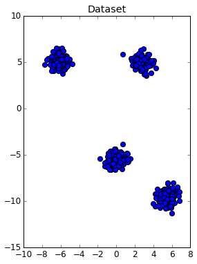

```
Results:
SEED = 245	H = 313.84
SEED = 40	H = 313.84
SEED = 705	H = 313.84
SEED = 441	H = 313.84
SEED = 877	H = 313.84


Comparisons:
Heterogeieity with baseline selection: 2868.28
Heterogeieity with kmean++ selection: 313.84
```

```python
# we use the same dataset used before

# change default figure and font size
plt.rcParams['figure.figsize'] = 8, 6
plt.rcParams['font.size'] = 12

# scatter plot
plt.scatter(X[:, 0], X[:, 1], s = 50)
plt.gca().set_aspect('equal')
plt.title('Dataset')
plt.show()

# Seeds are the same of the previous exercise
res_kpp = {}

for s in SEEDS:
    res_kpp[s] = kmeans(X, K, MAX_ITER, seed=int(s), select_centroids="kmeanpp")

print("\n\nResults:")
for i in range(len(SEEDS)):
    s = SEEDS[i]
    print("SEED = {}\tH = {}".format(int(s), round(res_kpp[s][2], 2)))

# print the average for the heterogeneity obtained with the seeds
print("\n\nComparisons: ")
print("Heterogeieity with baseline selection: {}".format(round(np.average([x[2] for x in res.values()]), 2)))
print("Heterogeieity with kmean++ selection: {}".format(round(np.average([x[2] for x in res_kpp.values()]), 2)))
```

Comparing this result with the one obtained before, we can see that the "kmeans++" technique is able to provide better results also for "bad" seed values. The reason is the one explained above: this technique is specifically designed in order to be able to select a good initial set of centroids. This is remarked by comparing the average heterogeneity obtained with the two implementations.

# Determining the value of k: a simple and visual approach, called the Elbow method

Another problem of $k$-means is that we have to specify the number of clusters $k$ before running the algorithm, which we often don't know a priori. There are many different heuristics for choosing a suitable value for $k$, the simplest one being the **Elbow method**. Essentially, the idea is to run the $k$-means algorithm using different values of $k$ and plot the corresponding heterogeneity. This measure will decrease as the number of clusters increases, because each cluster will be smaller and tighter. By visual inspection of the plot heterogeneity vs. $k$, we will (hopefully!) see that the curve flattens out at some value of $k$: this is what we call an "elbow", and we'll select the value of $k$ corresponding to the "elbow" position.

**Question 8.** Using the k-means algorithm you implemented, including the smart initialization technique, collect into an array the value of heterogeneity as a function of the number of clusters k, where k is to be selected in the range [2,10].  
Your output cell should contain:

- The plot of heterogeneity vs. k
- A discussion on your visual inspection of the curve, together with a justification for an appropriate choice of the value k

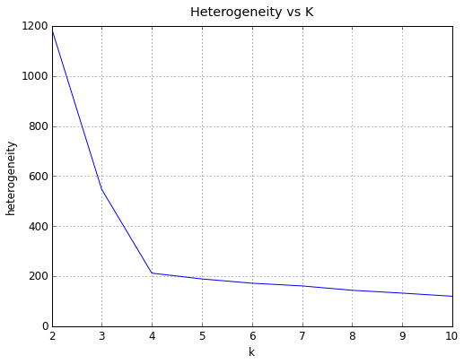

```python
heterogeneities = []

# we initialize the data set
X, y = make_blobs(n_samples = 300, centers = 4,
                  random_state = 0, cluster_std = 0.6)

for k in range(2, 11):
    centroids, labels, heterogen, running_time = kmeans(X, k, MAX_ITER, select_centroids="kmeanpp", seed=SEED)
    heterogeneities.append(heterogen)

# plotting the heterogeneity as a function of k
plt.plot(list(range(2, 11)), heterogeneities)
plt.title("Heterogeneity vs K", y=1.02)
plt.xlabel("k")
plt.ylabel("heterogeneity")
plt.grid()
plt.show()
```

According to the definition of heterogeneity, we can see that the its value decreases when the "k" value increases. This is due to the fact that, with high values of k, resulting clusters are smaller and more compact.  
The graph shows what the introduction of this exercise states: the improvement in heterogeneity value is greater in the start: once k reaches the value of 4 (sometimes 5, depending on the seed) the improvement decreases. Clearly, the heterogeneity value will be zero when k is equal to the number of elements in the dataset (single-element clusters): anyway, this would not be a useful result because the classification will not be effective nor meaningful.  
This is the reason why we are looking for a good value of k, able to generate a meaningful classification of tha data, avoid overfitting and alleviate the computation when we decide which cluster assign to every element of the dataset, at every iteration.

# Distributed $k$-means with PySpark

We're now ready to work on a distributed implmentation of the $k$-means algorithm, using the PySpark API.

By now, you should be rather familiar with the $k$-means algorithm, which means we can focus on its parallel and distributed design.

## Distributed algorithm pseudo code

The basic idea of distributed $k$-means is as follows: data points to be clustered should be stored as a distributed dataset, namely a RDD. As in the Notebook on distributed SGD, we will take a shortcut and avoid using HDFS RDDs: rather, we'll use sklearn to generate the data points, similary to the serial version of the algorithms, then use the `parallelize()` method to create an RDD, and determine the number of partitions.

We also need to manipulate the centroids array: indeed, all machines should hold a copy of the centroid vector, such that they can proceed independently and in parallel in the first phase of the $k$-means algorithm, that is the **assignment step**. Specifically, every worker has a set of data points, and it will use a copy of the centroid vector to compute cluster assignement: we compute the distance between each data point and each centroid, to assign data points to their closest centroid.

Once the assignement step is done, we need to recompute new centroids based on the assignement, that is, we execute the **update step**. Clearly, we will need to **shuffle** data over the network such that we will have, for each current centroid, the list of all data points that have been assigned to it. If you think about it, this problem should be familiar!! This is very similar to what we do in the Word Count example. As such, you will need to make sure the output of the update step is cast to a `<key, value>` type, where the key corresponds to a centroid identifier, and the value contains the list of data points associated to that centroid. The framework will take care of the distributed group by operation, and organize data according to the semantic of our algorithm.

**NOTE:** since we will (potentially) work on large dataset sizes, we don't want our algorithm to return the final assignement after convergence, for otherwise we would need to collect a large amount of data in the driver machine, which has a finite and somehow limited amount of RAM.

The pseudo code of the algorithm you need to implement is as follows:

```
datapoints = # Use sklearn, as usual, and work on blobs
centroids = # Random initialization

for itr in range(maxiter): # This for loop is executed by the driver
    bcCentroids = sc.broadcast(centroids) # Use broadcast variables

    closest = datapoints.mapPartition(assignement_step) # This should happen in parallel

    centroids = closest.reduceByKey(update_step_sum). \ # This should happen in parallel
        map(update_step_mean). \ # This should happen in parallel
        collect() # Here we collect new centroids in the driver
```

As you can see from the pseudo code, you need to figure out how to implement the `assignement_step` function and the update_step function. For the latter, the pseudo code gives you a big hint! Remember what we discussed in class about computing the mean!

**Question 9.** Implement the distributed version of the k-means algorithm, following the guidelines in the pseudo code.  
Your output cell should contain:

- The value of the centroids once the algorithm converges
- The total runtime of the distributed algorithm, in seconds
- A visualization of the data points and the computed centroids

```
Dataset size is: 46.98 KB
Algorithm's running time: 8 seconds

Obtained centroids:
[ 8.51147395 -9.27499433]
[ 7.09938516 -4.18572167]
[ 5.51847311 -1.91978018]
[ 3.35545553 -5.50604703]
[ 7.11705468  0.75011363]
[-6.57794601 -6.90264261]
[-7.04825098 -9.80674132]
[ 0.21005198 -2.46425739]
```

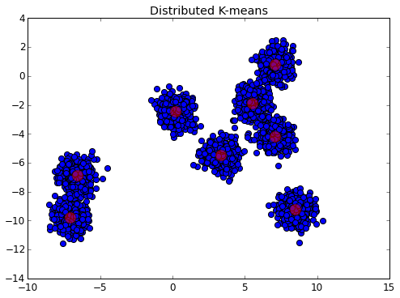

```python
import sys

def kmeans_d(X, k, max_iter, seed=None):
    '''
    #TODO
    '''
    # staring time
    start_time = time.time()

    # randomly choose k data points as initial centroids
    if seed is not None:
        np.random.seed(seed)
    n_row, n_col = X.shape
    rand_indices = np.random.choice(n_row, size = k, replace=False)
    centroids = X[rand_indices]

    # assign portions of the datasets to the workers
    dist_datapoints = sc.parallelize(X, 4).cache()

    for epoch in range(max_iter):
        # create a broadcast variable for the centroids
        bc_centroids = sc.broadcast(centroids)

        def assignment_step(worker_datapoints):
            for datapoint in worker_datapoints:
                # we want to keep, for every point, information about the nearest centroid
                dist = pairwise_distances(datapoint, bc_centroids.value, metric = 'euclidean')
                # the cluster id is the element position in the list
                cluster = np.argmin(dist)
                # output: key = cluster id, value = (datapoint, 1)  [to retrieve the average later]
                yield (cluster, [datapoint[0], datapoint[1], 1])

        def update_step_sum(a, b):
            # retrieve components of the value ("datapoint" and "counter")
            # note: the function takes the values for a given key, for which the groupBy is applied
            dp1_x = a[0]
            dp1_y = a[1]
            counter1 = a[2]
            dp2_x = b[0]
            dp2_y = b[1]
            counter2 = b[2]
            # sum the "datapoint" arrays content
            sum_dp_x = dp1_x + dp2_x
            sum_dp_y = dp1_y + dp2_y
            # emit pair with both fields summed
            return [sum_dp_x, sum_dp_y, counter1 + counter2]

        def update_step_mean(a):
            # to retrieve the mean, we divide the sum by the counter (getting rid of the key)
            key = a[0]
            value = a[1]
            s_x = value[0]
            s_y = value[1]
            c = value[2]
            return (key, [s_x/c, s_y/c])

        # retrieve new centroid values from workers
        res = dist_datapoints.mapPartitions(assignment_step, preservesPartitioning=True). \
                                        reduceByKey(update_step_sum). \
                                        map(update_step_mean). \
                                        collectAsMap()

        # retrieve the centroids coordinates
        new_centroids = np.array([res[key] for key in sorted(res.keys())])

        # stop condition
        if np.all(centroids == new_centroids):
            break
        else:
            # update centroid values, so that they will be broadcast in the next iteration
            #print(str(centroids) + '\n' + str(new_centroids) + '\n\n')
            centroids = np.copy(new_centroids)

    # end time
    end_time = time.time()
    # return obtained centroids and running time
    return new_centroids, end_time - start_time


# we initialize the data set
K = 8
SAMPLES = 3000
SEED = 12
MAX_ITER = 1000
X, y = make_blobs(n_samples = SAMPLES, centers = K,
                  random_state = 400, cluster_std = 0.6)

#print the dataset size
print('Dataset size is: {} KB'.format(round(sys.getsizeof(X)/1024, 2)))

centroids, running_time = kmeans_d(X, K, MAX_ITER, seed=SEED)

# print obtained centroids
print("Algorithm's running time: {} seconds".format(round(running_time)))
print("\nObtained centroids:")
for c in centroids:
    print(c)

centroids = np.array(centroids)


# print the scatter plot, with the dataset and the evaluated centroids
plt.scatter(X[:, 0], X[:, 1], s = 50, cmap="viridis")
plt.scatter(centroids[:, 0], centroids[:, 1], s = 200, alpha = 0.5, c='r')

plt.gca().set_aspect('equal')
plt.title("Distributed K-means")
plt.show()
```

**Question 10.** Answer the following questions:

- How many partitions did you use? Why?
- What is the size of the dataset you generate? Did you cache the dataset? What's the RAM occupation?
- What is the size of the shuffle data over the network? How does it compare to the dataset size?

**Answer 10.**

- As in the previous laboratory, we decided to instantiate 4 partitions because in the cluster there are 4 available workers, with one core each. In this way, I can achieve the best parallelization of the computation (each worker receive an input partion for each of its cores).
- The dataset size is 3000 samples: the "dist_datapoints" RDD is cached, because its content (the input dataset) is reused at every iteration of the algorithm. Dataset's RAM occupation is 46.98 KB (computed using the sys.getsizeof in python): input size is 139.2 KB (34.8 KB per worker). This was observed in the Spark Master Web Interface, under the storage page. The shuffle data was observed in the Stage detail page. The difference between the dataset's RAM occupation and the ParallelCollectionRDD's size is due to de-serialization, which almost increases the size up to three times.
- We are shuffling 4.9 KB over the network at each iteration: this quantity depends on the number of clusters "k" we want ot generate. The greater this value, the grater the amount of shuffled data. This is correlated to how the "reduceByKey" transformation works: every worker exchange with the others up to "k" intermediate results. This is an optimization done automatically by the framework, which can be seen as an "In-Mapper" combiner of the MapReduce paradigm.

**Question 11.** Comparison between serial and distributed implementations.  
Given the dataset size you chose for your experiments, answer the following questions:

- Which is "faster", the serial or distributed implementation of k-means?
- What is a dataset size for which the distributed implementation is clearly faster than the serial one?
- What would be different in your code, should the input dataset reside on disk? Clearly, the input RDD would be reading from HDFS. Any other differences with respect to partitions?

```
Dataset size is: 15.73 KB (1000 elements)
Dataset size is: 156.36 KB (10000 elements)
Dataset size is: 1562.61 KB (100000 elements)
Dataset size is: 15625.11 KB (1000000 elements)
```

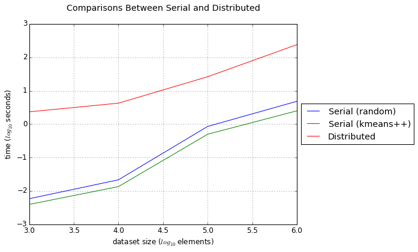

```python
DATASET_SIZES = [1e3, 1e4, 1e5, 1e6]
Ks = [4, 4, 4, 4]
MAX_ITER = 10
SEED = 11

serial_r_res = []
serial_pp_res = []
distributed_res = []

for i in range(len(DATASET_SIZES)):
    #create the dataset
    X, y = make_blobs(n_samples = int(DATASET_SIZES[i]), centers = Ks[i],
                      random_state = 11, cluster_std = 0.6)

    #print the dataset size
    print('Dataset size is: {} KB ({} elements)'.format(round(sys.getsizeof(X)/1024, 2), int(DATASET_SIZES[i])))

    #run the serial algorithm (random initial centroids choice)
    centroids, label, heterogen, running_time = kmeans(X, Ks[i], MAX_ITER, seed=SEED)
    serial_r_res.append(running_time)

    #run the serial algorithm (kmeans++)
    centroids, label, heterogen, running_time = kmeans(X, Ks[i], MAX_ITER, select_centroids="kmeanpp", seed=SEED)
    serial_pp_res.append(running_time)

    #run the distributed algorithm
    centroids, running_time = kmeans_d(X, Ks[i], MAX_ITER, seed=SEED)
    distributed_res.append(running_time)

#plot the obtained results
print("\n")
x_axes = np.log10(DATASET_SIZES)

plt.plot(x_axes, np.log10(serial_r_res))
plt.plot(x_axes, np.log10(serial_pp_res))
plt.plot(x_axes, np.log10(distributed_res))
plt.title("Comparisons Between Serial and Distributed", y=1.05)
plt.xlabel("dataset size ($log_{10}$ elements)")
plt.ylabel("time ($log_{10}$ seconds)")
plt.legend(['Serial (random)', 'Serial (kmeans++)', 'Distributed'], loc='center left', bbox_to_anchor=(1, 0.5))
plt.grid()
plt.show()
```

**Answer 11.**

- In our experiments, the serial implementation is faster than the distributed one. This because we have tried only with small datasets, indeed using 1e8 elements the driver crashed raising an OutOfMemoryError. In order to see real benefits from the disributed, we should allocate a dataset of serveral GB or even PB in the HDFS and use it instead of parallelize. Pleas note that we had to limit the number of iterations for running the different experiments in order to run them in a reasonable time.
- As a general rule, there is a dataset size threshold over which the distributed implementation is faster then the serial one. This size value justify the involvement of several workers and the framework overhead that is needed to synchronize their work. Clearly, if the dataset cannot fit the main memory of a single machine the distributed approach will be the best one: swap would occur, degrading the performances. When the dataset size is larger that the total amount of memory a single machine can dispose, the algorithm has to be executed following the distributed approach.
- Clearly, if the dataset is huge it should reside on a file stored into disk (splitted in blocks according to how HDFS operates). When the dataset resides on disk, the code we have written has to be modified: in fact, we are generating the starting RDD reading the input as a list. In order to retrieve data from a file, the method "textFile" has to be called instead of "parallelize" (specifing the filename and, eventually, the number of partitions to create). The "persist" method ("cache", in our code) become more relevant in this scenario, allowing to save the time required to read again input data from HDFS.